# DATA 550 Lab 2 - EDA on movie data

There are two versions of this lab, one in Python and one in R. The R lab will use `ggplot` and the Python lab will use `Altair`.

This is the R version.

Each partner should choose a version to complete, though keep in mind that **you are required to alternate between completing the R labs and the Python labs** to get experience using both languages.

## Acknowledgemnts

This lab was lightly adapted from the one created by Joel Ostblom for the DSCI 531 version of Data Viz I in the 2020/21 Academic year.

## Submission instructions

rubric={mechanics:2}

You receive marks for submitting your lab correctly, please follow these instructions:

- Each partner should complete one file, though collaboration is permitted.
- Push your `.ipynb` files to GitHub frequently (i.e. not just in one fell swoop at the end).
- Don't forget to submit a clickable link to your GitHub repo on Canvas so we can grade it.

# 0. Get motivated!

I have heard that the movie market is a lucrative business, and have been looking into starting my own online streaming service together with a few friends. Before we do this, we need to understand the movie market better so that we can get a competitive edge over existing service. I have been looking all over for an aspiring data wrangler and future VIZARD, but haven't been able to track one down. This is where you come in!

Together, we must understand the current movie market, which companies produces what kind of movies, and which receive good scores. Then we can have the best movies on our platform and show only those, easy right? I mean...we will show only good movies, I can't believe no one has thought of this before! I have already identified a unique name for this service: Bestflix™.

Don't worry, we're in this together and I will be helping you with the wrangling throughout most exercises if you take charge of the viz part, deal?. Also, I have never failed to start a company before, so you're in good hands. I can already smell the `$$$`, so let's get started!

In this notebook, we will focus on Exploratory Data Analysis (EDA), both for single numerical columns, pairwise numerical columns, numerical columns conditioned on categorical columns and combinations of categorical columns.

# 1. Single numerical columns

### Question 1.1

rubric={reasoning:1,accuracy:1}

#### R

In the beginning of EDA, it can be good to look at some textual summaries, just to get an idea of what to plot. The data file is caled `lab2-movies.json`. Read it in using the sample code below, then do the following in three different cells:

1. Display the first few rows of the data.
2. Display info about all columns, including their data types.
3. Display a summary description of the data frame's numerical columns only.

```python
#install.packages("rjson")
```

```python
library(rjson)
library(tidyverse)

movies <- rjson::fromJSON(file = 'data/lec-movies.json') %>%
    as_tibble() %>%
    mutate(
        id = unlist(id),
        title = unlist(title),
        runtime = as.numeric(unlist(runtime)),
        budget = as.numeric(unlist(budget)),
        revenue = as.numeric(unlist(revenue)),
        vote_average = as.numeric(unlist(vote_average)),
        vote_loved_it = as.numeric(unlist(vote_loved_it)),
        vote_count = as.numeric(unlist(vote_count)),
        vote_std = as.numeric(unlist(vote_std)),
        genres = sapply(genres, function(x) paste(x, collapse = ", ")),          # use lambda functions to unpack list of vectors
        countries = sapply(countries, function(x) paste(x, collapse = ", "))
    )
```

[output not shown]

```python
# 1. Display the first few rows of the data.

head(movies, 3)
```

[output not shown]

```python
# 2. Display info about all columns, including their data types.
str(movies)
```

```
tibble [680 × 11] (S3: tbl_df/tbl/data.frame)
 $ id           : Named num [1:680] 12 22 35 58 75 117 118 120 121 122 ...
  ..- attr(*, "names")= chr [1:680] "0" "1" "2" "3" ...
 $ title        : Named chr [1:680] "Finding Nemo" "Pirates of the Caribbean: The Curse of the Black Pearl" "The Simpsons Movie" "Pirates of the Caribbean: Dead Man's Chest" ...
  ..- attr(*, "names")= chr [1:680] "0" "1" "2" "3" ...
 $ runtime      : num [1:680] 100 143 87 151 106 119 115 178 179 201 ...
 $ budget       : num [1:680] 9.4e+07 1.4e+08 7.5e+07 2.0e+08 7.0e+07 2.5e+07 1.5e+08 9.3e+07 7.9e+07 9.4e+07 ...
 $ revenue      : num [1:680] 9.40e+08 6.55e+08 5.27e+08 1.07e+09 1.01e+08 ...
 $ genres       : Named chr [1:680] "Animation" "Fantasy" "Animation" "Fantasy" ...
  ..- attr(*, "names")= chr [1:680] "0" "1" "2" "3" ...
 $ countries    : Named chr [1:680] "United States of America" "United States of America" "United States of America" "United States of America" ...
  ..- attr(*, "names")= chr [1:680] "0" "1" "2" "3" ...
 $ vote_average : num [1:680] 3.86 3.81 3.44 3.47 2.96 3.88 3.23 4.1 4.08 4.11 ...
 $ vote_loved_it: num [1:680] 0.322 0.32 0.155 0.198 0.086 0.268 0.13 0.515 0.498 0.524 ...
 $ vote_count   : num [1:680] 33887 36337 8621 15079 19515 ...
 $ vote_std     : num [1:680] 0.87 0.91 0.92 0.98 1.1 0.78 1.01 0.99 0.98 0.99 ...
```

```python
# 3. Display a summary description of the data frame's numerical columns only.
movies %>%
    select(where(is.numeric)) %>%
    summary()
```

```
       id            runtime          budget             revenue
 Min.   :    12   Min.   : 26.0   Min.   :        8   Min.   :1.600e+01
 1st Qu.:  5919   1st Qu.: 92.0   1st Qu.: 25000000   1st Qu.:3.814e+07
 Median : 11228   Median :104.0   Median : 55000000   Median :1.118e+08
 Mean   : 54944   Mean   :109.6   Mean   : 69841766   Mean   :2.262e+08
 3rd Qu.: 51502   3rd Qu.:122.2   3rd Qu.:100000000   3rd Qu.:3.047e+08
 Max.   :402298   Max.   :248.0   Max.   :380000000   Max.   :2.788e+09
  vote_average   vote_loved_it     vote_count       vote_std
 Min.   :0.630   Min.   :0.000   Min.   :    5   Min.   :0.230
 1st Qu.:2.920   1st Qu.:0.083   1st Qu.:  666   1st Qu.:0.930
 Median :3.280   Median :0.135   Median : 2106   Median :1.000
 Mean   :3.226   Mean   :0.159   Mean   : 6049   Mean   :1.009
 3rd Qu.:3.580   3rd Qu.:0.218   3rd Qu.: 6547   3rd Qu.:1.080
 Max.   :4.270   Max.   :0.547   Max.   :67662   Max.   :1.960
```

### Question 1.2

rubric={viz:1,accuracy:1,reasoning:1}

#### R

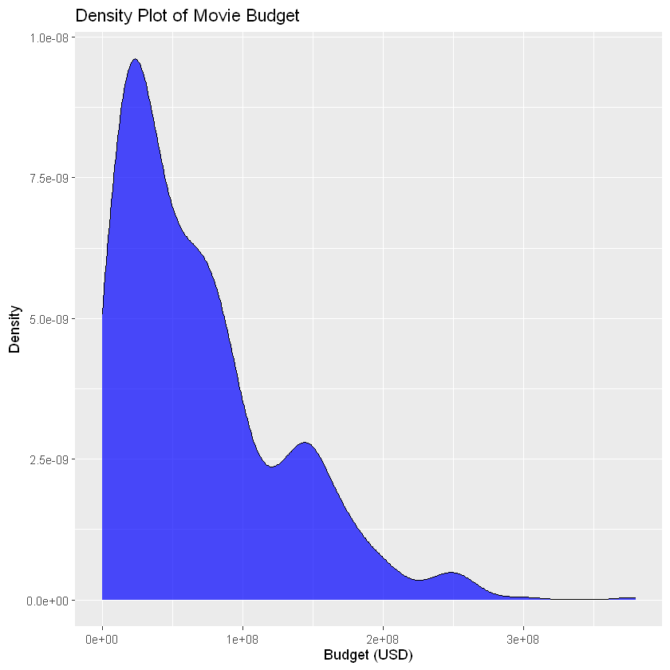

```python
# YOUR ANSWER GOES HERE
movies %>%
    ggplot(aes(x=budget)) +
    geom_density(alpha = 0.7, fill = "blue") +
    labs(
        title = "Density Plot of Movie Budget",
        x = "Budget (USD)",
        y = "Density"
        )
```

Histograms provide a better understanidng of the underlying data because it shows the actual counts/frequencies of each movie and it also helps identifies gaps in the data clearly. Another reason is that it is easier to read exact values in a histogram, compared to a density plot.

### Question 1.3

rubric={viz:2,accuracy:2}

#### R

- Pipe the data fame's numerical columns (except `id`) into ggplot (the `.select_if()` method can help here, or you can do it manually).
- Copy the code from your density plot above and paste it here. Modify the code so that it accepts the piped dataframe and plots one density estimate per column in a plot grid with 2 columns and 3 rows. Don’t use a loop, use pivoting and faceting instead (example in the lecture videos).

[figure not shown]

```python
# YOUR ANSWER GOES HERE
movies %>%
    select(where(is.numeric), -id) %>%
    pivot_longer(
        cols = everything(),
        names_to = "variable",
        values_to = "value"
    ) %>%
    ggplot(aes(x = value)) +
    geom_density(alpha = 0.7, fill = "blue") +
    facet_wrap(~ variable, ncol = 2) +
    labs(
        title = "Density Plot of Numeric Movie Variables",
        x = "Value",
        y = "Density"
        )
```

# 2. Pairwise numerical columns

### Question 2.1

rubric={viz:1,accuracy:1}

#### R

Next, let’s look at the relationships between pairs of numerical columns.For this we will create a scatterplot matrix (SPLOM) for all numerical columns except `id`.

There is nothing built into `ggplot` for this but the `GGally` package has a handy `ggpairs` function for this, which also plots single column densities on the diagonal and correlation coefficients on the upper corner. Install this package an then use the `ggpairs`.

```python
# YOUR ANSWER GOES HERE
#install.packages('GGally')
```

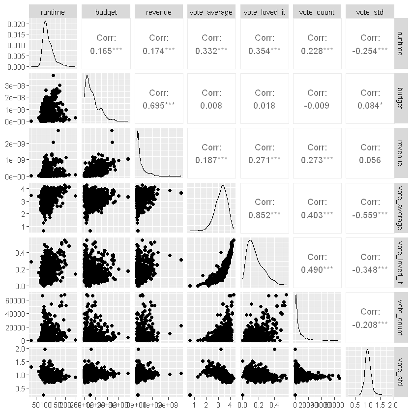

```python
library(GGally)

movs_numeric <- movies %>%
    select(where(is.numeric), -id)

ggpairs(movs_numeric)
```

### Question 2.2 (Optional)

rubric={accuracy:0.5,reasoning:0.5}

#### R

We're getting close, dont give up! Remember, we're in it for the `$$$`

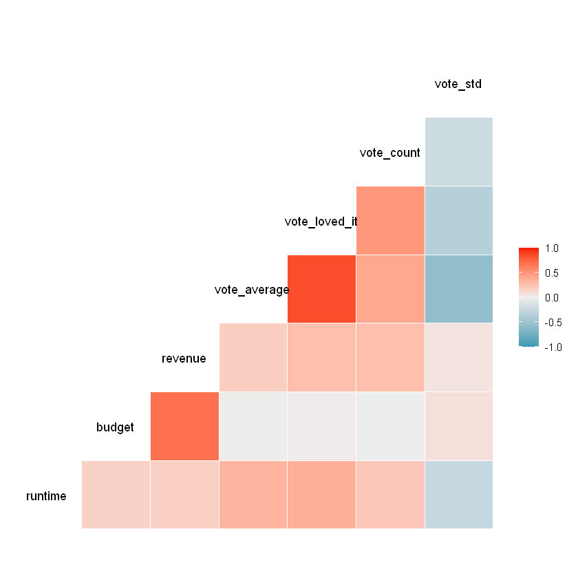

```python
# YOUR ANSWER GOES HERE
library(GGally)

ggcorr(movs_numeric)
```

I prefer the ggpair visualization since it provides much more information, as well as the exact correlation coefficients, compared to the ggcorr plot that is just a heatmap of the correlation cofficient. Therefore, since the ggpair visulization is easier to interpret and has more important detail, I prefer that plot.

# 3. EDA of numerical columns conditioned on a categorical column (genres)

### Question 3.1

rubric={viz:1,accuracy:2}

#### R

Let's create a explosion in R. In the tidyverse, exploding a list / vector from a column is referred to as unnesting it, less action-packed but maybe even more descriptive? =)

I have already done the necessary wrangling here, but please view the df so that you understand what happened and [check out tidyr doc for a simpler example](https://tidyr.tidyverse.org/reference/nest.html).

1. Use this new dataframe and create multiple violinplots inside a single figure by having genres on the y-axis and revenue on the x axis.
2. Read the documentation of the violin plot to find out how you can use its parameters to add a line for the median (hint: the same as quantile 0.5).
3. As we did in the previous lecture with `add_count()`, we need to create a new column for sorting, this time using `mutate()`. I want you to sort the genres by median revenue, so that the median lines of the violin plots are nicely sorted. I have given you a skeleton below where you can fill in the blanks, but you are also free to do it your own way. Then use the same function as previous lectures to sort by this new column.

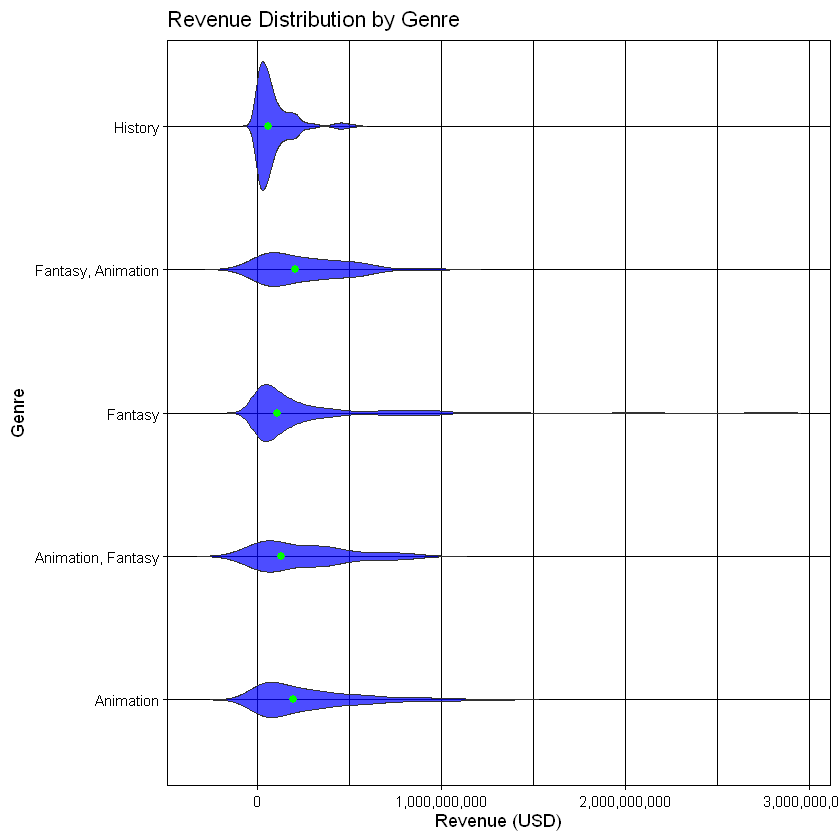

```python
free_genres <- movies %>%
  unnest(genres)

genre_meds <- free_genres %>%
  group_by(genres) %>%
  summarise(
    median_revenue = median(revenue, na.rm = TRUE),
    .groups = "drop"
  )

ggplot(free_genres, aes(x = revenue, y = genres)) +
  geom_violin(
    trim = FALSE,
    fill = "blue",
    alpha = 0.7
  ) +
  geom_point(
    data = genre_meds,
    aes(x = median_revenue, y = genres),
    color = "green",
    size = 2
  ) +
  scale_x_continuous(labels = scales::comma) +
  labs(
    title = "Revenue Distribution by Genre",
    x = "Revenue (USD)",
    y = "Genre"
  ) +
  theme_linedraw()
```

### Question 3.2

rubric={viz:1,accuracy:2}

Don't give up soldier, you're almost done with this lab! Bestflix future rests with you.

#### R

1. Copy the code from your violinplot above and use the same faceting strategy as for the histograms to repeat this violinplot for all numerical values (you don't need to sort the y-axis by different columns, it is better that categories are sorted by median revenue in all facets so that we don't have to keep track of how they move around between subplots).
   - In contrast to the histograms you will here need to save the genres and medium_revenue columns by using the `!` syntax in your call to `pivot_longer`, see the [example in the manual for how to do this](https://tidyr.tidyverse.org/reference/pivot_longer.html).
   - You will also need to define both x and y in your `aes()`, just like in the single violinplot you made above.

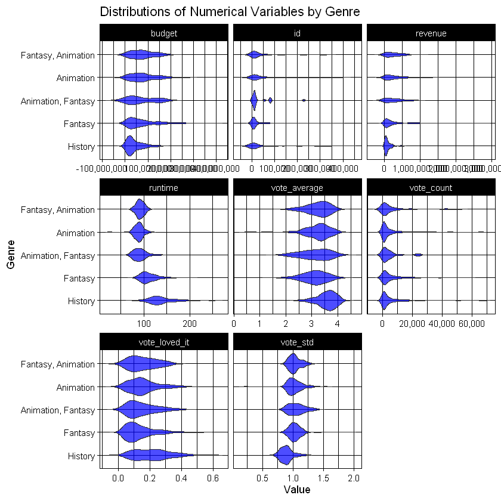

```python
free_genres <- movies %>%
  unnest(genres)

genre_order <- free_genres %>%
  group_by(genres) %>%
  summarise(median_revenue = median(revenue, na.rm = TRUE)) %>%
  arrange(median_revenue) %>%
  pull(genres)

free_genres <- free_genres %>%
  mutate(genres = factor(genres, levels = genre_order))

movies_long <- free_genres %>%
  pivot_longer(
    cols = where(is.numeric),
    names_to = "variable",
    values_to = "value"
  )

ggplot(movies_long, aes(x = value, y = genres)) +
  geom_violin(
    trim = FALSE,
    fill = "blue",
    alpha = 0.7
  ) +
  facet_wrap(~ variable, scales = "free_x") +
  scale_x_continuous(labels = scales::comma) +
  labs(
    title = "Distributions of Numerical Variables by Genre",
    x = "Value",
    y = "Genre"
  ) +
  theme_linedraw()
```

### Question 3.3 (Optional)

rubric={accuracy:0.5,reasoning:0.5}

#### R

```python
# YOUR ANSWER GOES HERE
ggplot(movies_long, aes(x = value, y = genres)) +
  geom_violin(
    trim = FALSE,
    scale = "count",
    fill = "blue",
    alpha = 0.7
  ) +
  facet_wrap(~ variable, scales = "free_x") +
  scale_x_continuous(labels = scales::comma) +
  labs(
    title = "Distributions of Numerical Variables by Genre",
    x = "Value",
    y = "Genre"
  ) +
  theme_linedraw()
```

[output not shown]

The approach that we used with Altair is much better since the combination of a boxplot and barplot makes it easier to see the number of observations in an accurate and clearer way than using violin plots.

### Question 3.4 (Optional)

rubric={accuracy:0.5,reasoning:0.5}

#### R

Let’s see how the numerical columns vary with different production studios.

1. Create a new dataframe from exploding/unnesting the `studios` column in the `movies` dataframe. You can use my code from above to guide you.
2. Create a similar sorting list as before, but this time with the studies sorted by median revenue.
3. Create the same repeated boxplots for the studios. A tip when you are creating similar plots for two different sections of your notebook, is to use a different color for each so that it is easy to orient yourself (unless you are encoding color as a visual aesthetic of course, but we’re not doing that here). Pick any HTML color either via its hex code or by choosing a name from [this list of named colors](https://stackoverflow.com/a/37232759/2166823). Color all the bars and boxes in this color by setting it inside `mark_boxplot()` / `geom_boxplot()`.
4. Create the same barplot of counts as above for the studios. Color the bars in the same colors as the boxplots.
5. Reflect on the information in the boxplot and / or the barplot. Identify two interesting relationships / questions / discoveries that stand out to you and that you would want to explore further. Briefly motivate why (<90 words).

```python
# YOUR ANSWER GOES HERE FOR THE REPEATED BOXPLOT
```

```python
# YOUR ANSWER GOES HERE FOR THE BAR PLOT OF COUNTS
```

# 4. EDA of categorical columns

### Question 4.1

rubric={viz:1,accuracy:1}

1. Go through the [GGally example plots](http://ggobi.github.io/ggally/articles/ggally_plots.html) and find a plot that you think is suitable for showing the count of the combination of categorical variables. Use this plot to visualize the counts.
2. Create another plot of the counts by first using `add_count()` to add a count for all the combinations of genres and studios. This column will be called `n` and you can map it to an appropriate aesthetics encoding and visualize the results with `geom_tile` to create a heatmap of counts.

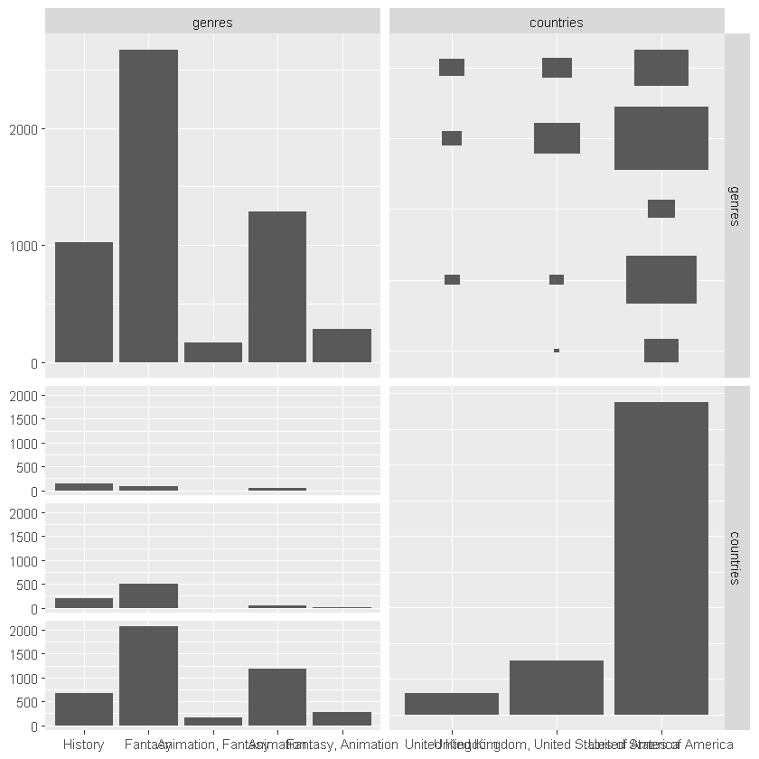

```python
categorical_df <- movies_long %>%
  select(genres, countries)

ggpairs(
  categorical_df,
  upper = list(continuous = "blank", combo = "blank"),
  lower = list(combo = "count")
)
```

[figure not shown]

```python
movie_counts <- movies_long %>%
    add_count(genres, countries, name = "n")

ggplot(movie_counts, aes(x = countries, y = genres, fill = n)) +
  geom_tile() +
  scale_fill_gradient(low = "white", high = "steelblue") +
  labs(
    title = "Heatmap of Movie Counts by Genre and Countries",
    x = "Country",
    y = "Genre",
    fill = "Count"
  ) +
  theme_minimal() +
  theme(
    axis.text.x = element_text(angle = 45, hjust = 1)
  )
```

### Question 4.2 (Optional)

rubric={accuracy:1}

#### R

The plots above are great for comparing absolute counts, but that means that studios with smaller production volume gets drowned out. Let's instead visualize the proportion within each studio for each genre. Calculate the proportion for each studio - genre pair, so that for each studio, the genre proportions adds up to 1. Visualize with your favorite categorical count plot.

```python
# YOUR ANSWER GOES HERE
```

# Submission to Canvas

When you are ready to submit your assignment do the following:

1. Run all cells in your notebook to make sure there are no errors by doing `Kernel -> Restart Kernel and Run All Cells...`
2. Commit and push all your work (including the .ipynb file) to GitHub.
3. Submit a link to your repo on Canvas (this has to be done only once per group).